# Nathan Hotdogs

We will be reproducing the code in Section 12.4 of Benjamin Baumer, Daniel Kaplan and Nicholas Horton’s book [MDSR](https://beanumber.github.io/mdsr2e/ch-vizIII.html#extended-example-hot-dog-eating). The original graphic we are trying to reproduce is from [here](https://flowingdata.com/2008/07/03/nathans-annual-hot-dog-eating-contest-kobayashi-vs-chestnut/hot-dogs/).

[figure not shown]

It was said that the figure was generated in **R** and then edited in **Adobe Illustrator**. The following code taken from Baumer et al. illustrate how far one can goes (without too much effort) in reproducing the figure using **R** itself.

## Loading the data.

First we load in the data; the data is given as a csv file.

```r
library(dplyr) ## To get the '%>%' operator and the bind_rows function.
hd <- readr::read_csv("http://datasets.flowingdata.com/hot-dog-contest-winners.csv")
names(hd) <- gsub(" ", "_", names(hd)) %>% ## Replace " " by "_" in column names
  tolower() ## Convert column names to lower case
hd
```

```
## # A tibble: 31 x 5
##    year winner                       dogs_eaten country       new_record
##   <dbl> <chr>                             <dbl> <chr>              <dbl>
## 1  1980 Paul Siederman & Joe Baldini        9.1 United States          0
## 2  1981 Thomas DeBerry                     11   United States          0
## 3  1982 Steven Abrams                      11   United States          0
## 4  1983 Luis Llamas                        19.5 Mexico                 0
## 5  1984 Birgit Felden                       9.5 Germany                0
## 6  1985 Oscar Rodriguez                    11.8 United States          0
## # … with 25 more rows
```

The *hd* data frame does not contain any observations before $1980$. We estimate the values for these observations from the original figure.

```r
new_data <- data.frame(
  year = c(1979, 1978, 1974, 1972, 1916),
  winner = c(NA, "Walter Paul", NA, NA, "James Mullen"),
  dogs_eaten = c(19.5, 17, 10, 14, 13),
  country = rep(NA, 5), new_record = c(1,1,0,0,0)
)
hd <- bind_rows(hd, new_data)
```

## First plot

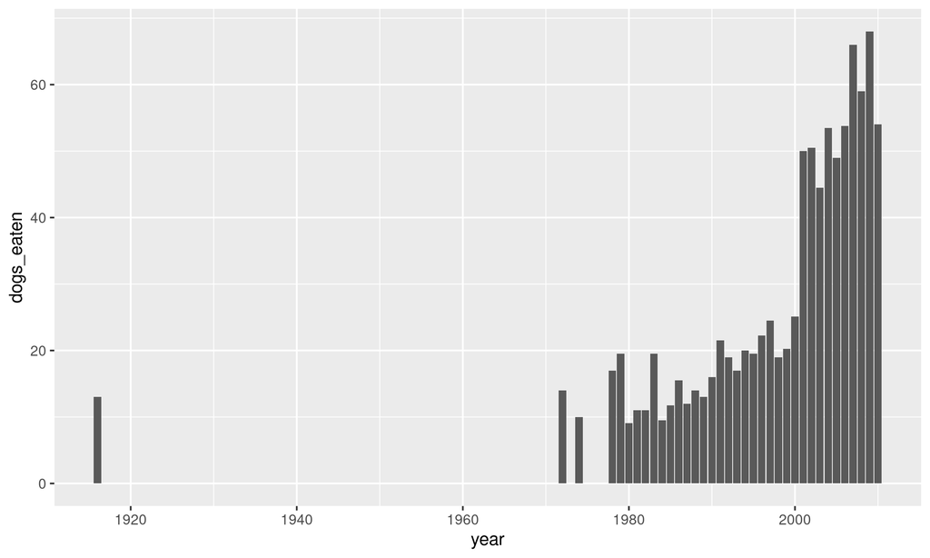

```r
library(ggplot2)
p <- ggplot(data = hd, aes(x = year, y = dogs_eaten)) +
  geom_col()
p
```

The resulting plot is functional, but not terribly exciting. Time for some dressup. First color the observations by whether it is a new world record.

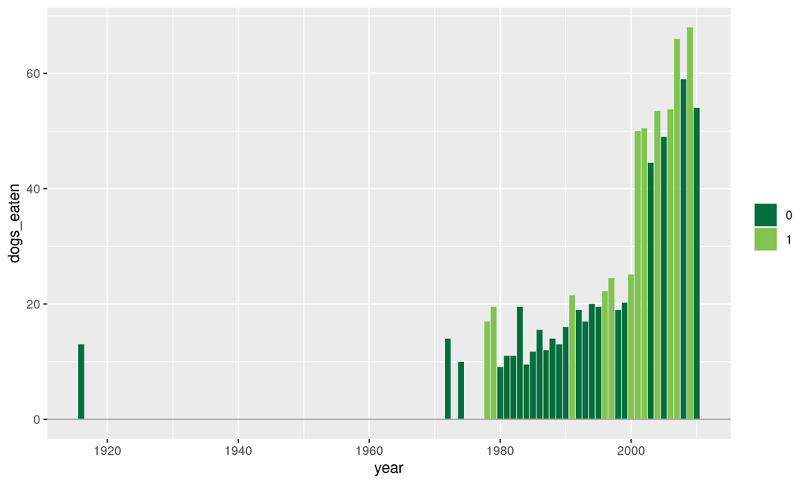

```r
p <- p + geom_col(aes(fill = factor(new_record))) +
  geom_hline(yintercept = 0, color = "darkgray") +
  scale_fill_manual(name = NULL, values = c("0" = "#006f3c", "1" = "#81c450"))
p
```

## Adding the annotations text

We first create a dataframe containing the locations for the annotation texts.

```r
text <- bind_rows(
  # Frank Dellarosa
  data.frame(x = 1941.5, y = 37,
    label = paste("Frank Dellarosa eats 21 and a half HDBs over 12\n",
      "minutes, breaking the previous record of 19 and a half."), adj = 0),
  # Joey Chestnut
  data.frame(x = 1966.5, y = 69,
    label = paste("For the first time since 1999, an American\n",
      "reclaims the title when Joey Chestnut\n",
      "consumes 66 HDBs, a new world record."), adj = 0),
  # Kobayashi
  data.frame(x = 1950.5, y = 55,
    label = paste("Through 2001-2005, Takeru Kobayashi wins by no less\n",
      "than 12 HDBs. In 2006, he only wins by 1.75. After win-\n",
      "ning 6 years in a row and setting the world record 4 times,\n",
      "Kobayashi places second in 2007."), adj = 0),
  # Walter Paul
  data.frame(x = 1938, y = 26, label = "Walter Paul sets a new
world record with 17 HDBs.", adj = 0),
  # James Mullen
  data.frame(x = 1917, y = 10, label = "James Mullen wins the inaugural
contest, scarfing 13 HDBs. Length
of contest unavailable.", adj = 0),
  data.frame(x = 1935, y = 72, label = "NEW WORLD RECORD"),
  data.frame(x = 1914, y = 72, label = "Hot dogs and buns (HDBs)")
)
```

We now add the annotation text, and remove the unnecessary legend/guide on the right.

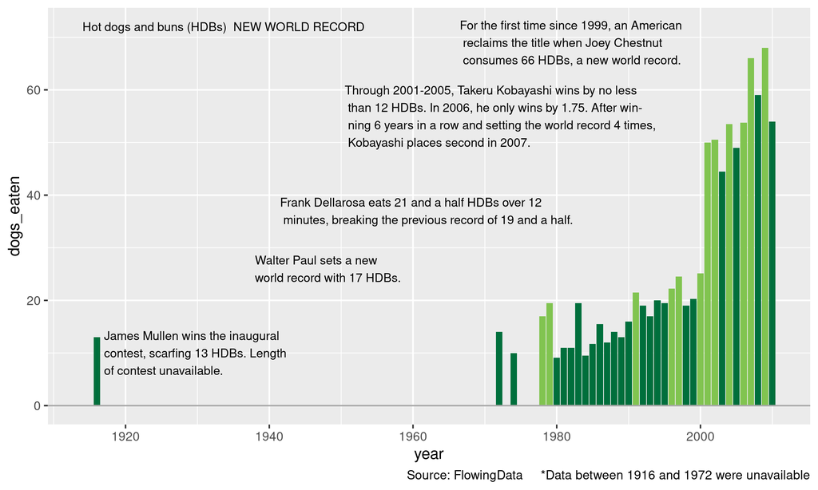

```r
p <- p +
  geom_text(data = text, aes(x = x, y = y, label = label), hjust = "left", size = 3) +
  labs(caption = "Source: FlowingData     *Data between 1916 and 1972 were unavailable") +
  guides(fill = FALSE)
p
```

## Adding the connecting segments from text labels to the bars.

We now create a data frame defining the gray line segments in the original figure.

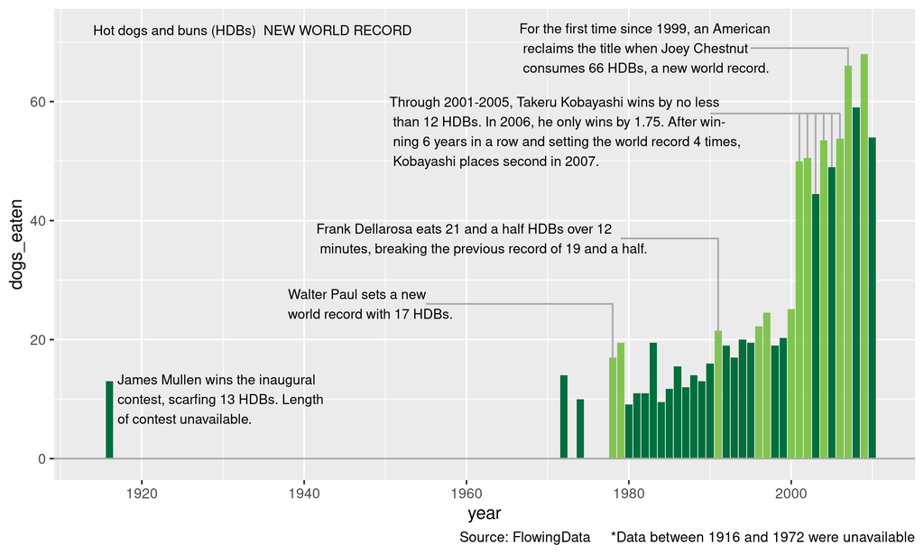

```r
## Read ?geom_path
segments <- bind_rows(
  data.frame(x = c(1979, 1991, 1991, NA), y = c(37, 37, 21, NA)),
  data.frame(x = c(1995, 2007, 2007, NA), y = c(69, 69, 66, NA)),
  data.frame(x = c(1990, 2006, 2006, NA), y = c(58, 58, 53.75, NA)),
  data.frame(x = c(2005, 2005, NA), y = c(58, 49, NA)),
  data.frame(x = c(2004, 2004, NA), y = c(58, 53.5, NA)),
  data.frame(x = c(2003, 2003, NA), y = c(58, 44.5, NA)),
  data.frame(x = c(2002, 2002, NA), y = c(58, 50.5, NA)),
  data.frame(x = c(2001, 2001, NA), y = c(58, 50, NA)),
  data.frame(x = c(1955, 1978, 1978), y = c(26, 26, 17)))
p <- p + geom_path(data = segments, aes(x = x, y = y), col = "darkgray")
p
```

## Finishing up

We are almost done. The only things left to do is to setup the locations of the tickmarks, add the key (depicting when is a new record), and remove the axes labels. Not bad for half a day of work ?

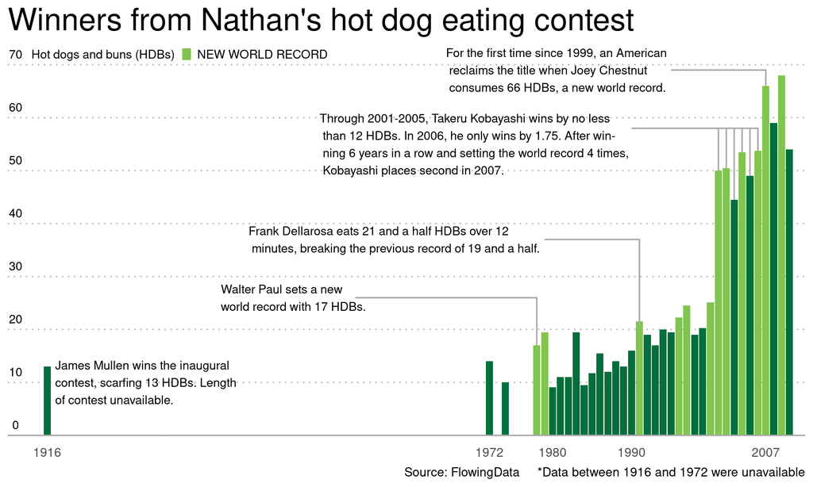

```r
xlabs <- c(1916, 1972, 1980, 1990, 2007)
ylabs <- seq(from = 0, to = 70, by = 10)
ticks_y <- data.frame(x = 1912, y = ylabs)

p <- p +
  scale_x_continuous(name = NULL, breaks = xlabs, minor_breaks = NULL,
                     limits = c(1912, 2011), expand = c(0, 1)) +
  scale_y_continuous(name = NULL, breaks = ylabs, labels = NULL, minor_breaks = NULL,
                     expand = c(0.01, 1)) +
  geom_text(data = ticks_y, aes(x = x, y = y + 2, label = y), size = 3) +
  ggtitle("Winners from Nathan's hot dog eating contest") +
  geom_rect(xmin = 1933, ymin = 70.75, xmax = 1934.3, ymax = 73.25,
            fill = "#81c450", color = "white") + ## Key
  theme(panel.background = element_rect(fill = "white"),
        panel.grid.major.y = element_line(color = "gray", linetype = "dotted"),
        plot.title = element_text(size = rel(2)),
        axis.ticks.length = unit(0, "cm"))
p
```